# Regression Model Notebook

Jackson Chou

This is a collection of notes/scripts from the Regression course. Lots of exercises done here are just following examples from lecture videos and practice problems.

## Week 2 - Linear Regression for Prediction

Example is taking the diamond dataset from UsingR. Data is diamond prices (Singapore dollars) and diamond weight in carats (standard measure of diamond mass, 0.2 $g$).

Loading diamond dataset:

```r
install.packages('UsingR')
library(UsingR)
data(diamond)
```

### Plot the dataset

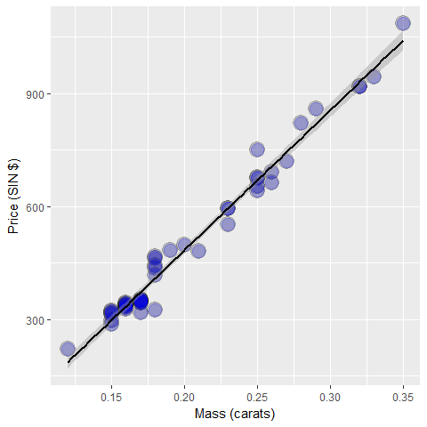

The fitted line in the plot is the regression line. This line minimizes the sum of squared vertical distances between the data points.

### Fitting the linear regression model

```r
fit <- lm(price ~ carat, data = diamond)
coef(fit)
```

```
(Intercept)       carat
  -259.6259   3721.0249
```

This prints out the coefficients for $\beta_i$ and $Y$. However, we can also use summary() to print out the entire diagonostics of the regression model.

```r
summary(fit)
```

```
Call:
lm(formula = price ~ carat, data = diamond)

Residuals:
    Min      1Q  Median      3Q     Max
-85.159 -21.448  -0.869  18.972  79.370

Coefficients:
            Estimate Std. Error t value Pr(>|t|)
(Intercept)  -259.63      17.32  -14.99   <2e-16 ***
carat        3721.02      81.79   45.50   <2e-16 ***
---
Signif. codes:  0 ‘***’ 0.001 ‘**’ 0.01 ‘*’ 0.05 ‘.’ 0.1 ‘ ’ 1

Residual standard error: 31.84 on 46 degrees of freedom
Multiple R-squared:  0.9783,    Adjusted R-squared:  0.9778
F-statistic:  2070 on 1 and 46 DF,  p-value: < 2.2e-16
```

### Getting a more interpretable intercept

```r
fit2 <- lm(price ~ I(carat - mean(carat)), data = diamond)
coef(fit2)
```

```
           (Intercept) I(carat - mean(carat))
              500.0833              3721.0249
```

### Predicting the price of a diamond

```r
newx <- c(.16, .27, .34)
coef(fit)[1] + coef(fit)[2] * newx
```

[output not shown]

You can also use the predict() function to get the same answer. The function is more helpful when dealing with more variables in the models.

```r
predict(fit, newdata = data.frame(carat = newx))
```

[output not shown]

## Residuals

Residuals represent variation left unexplained by our model. We emphasize the difference between residuals and errors. The errors are unobservable true errors from the known coefficients, while residuals are the observable errors from the estimated coefficients. In a sense, the residuals are estimates of the errors.

```r
y <- diamond$price
x <- diamond$carat
n <- length(y)
fit <- lm(y~x)
e <- resid(fit)
yhat <- predict(fit)
max(abs(e - (y-yhat)))
```

```
[1] 9.485746e-13
```

```r
max(abs(e - ( y - coef(fit)[1] - coef(fit)[2] * x)))
```

```
[1] 9.485746e-13
```

### Heteroskedasticity

While the plot below seems like a good fit, falling along the regression line. We still need to take a look at the residual plots.

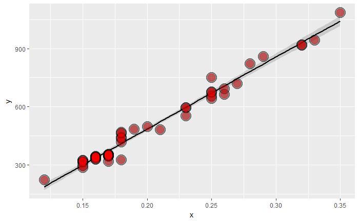

### Residual plot

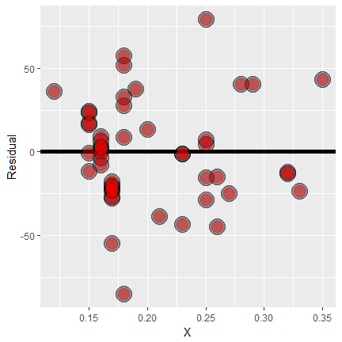